# Figure 5: $\Delta$Velocity and SI Ratio in other Female Stress Models

In Figure 5 we show that $\Delta$Velocity changes are observed in Chronic Social Non-Discriminatory Defeat (CSNDS) as well as Urine Model Defeat. This code generates Figure 5 as well as statistics for the results section **Exploration of** $\Delta$**Velocity across female social stress models.**

### Libraries & Config

```r
library(here)
library(glue)
library(dplyr)
library(tidyr)
library(magrittr)
library(ggplot2)
library(cowplot)
library(effectsize)
library(emmeans)
library(pander)
library(knitr)
```

```r
source(here('styles.R'))
data_path <- here('data')
primary_diff <- readRDS(glue('{data_path}/SIT_diff_primary.rds'))
secondary_diff <- readRDS(glue('{data_path}/SIT_diff_secondary.rds'))

# Bind primary and secondary DFs
primary_diff %<>%
    filter(Sex == 'Female') %>%
    mutate(model = 'CSW/DS',
           lab = 'bagot',
           other = NA) %>%
    select(names(secondary_diff))
SIT_diff <- bind_rows(primary_diff, secondary_diff) %>%
                      mutate(other = ifelse(is.na(other), 'None', other))
```

### SI ratio across female defeat models (Fig. 5a-d)

SI ratio is significantly lower in stressed females Urine model defeat, but not following CSNDS or in a validation cohort of CSW/DS. In male witnesses, SI ratio is not significantly reduced either. In CSNDS males and in the males of the CSW/DS validation cohort, SI ratio is as expected significantly reduced.

```r
SIT_diff %>%
  filter(model %in% c('CSW/DS VC F', 'CSW/DS VC M','CSW/DS Witness M', 'CSNDS Female', 'CSNDS Male', 'Urine'),
         other != 'ELS') %>%
  mutate(model = factor(model, levels = c('CSW/DS VC F', 'CSW/DS VC M','CSW/DS Witness M', 'CSNDS Female', 'CSNDS Male', 'Urine')),
         colcond = paste0(Sex, Condition)) -> main_SIT_diff

# PLOT ----
SI_ratio <- ggplot(main_SIT_diff, aes(Condition, IZ_time, color = colcond, fill = colcond)) +
                geom_hline(yintercept = 1, color = 'gray10') +
                geom_jitter(width = 0.2, alpha = 0.2, height = 0) +
                stat_summary(fun = 'mean', geom = 'point', size = 2) +
                stat_summary(fun.data = 'mean_se', geom = 'errorbar',
                             linewidth = 1, width = 0.4) +
                facet_grid(. ~ model) +
                scale_y_continuous(name = 'SI Ratio',
                                   breaks = c(0,1,2,3,4), limits = c(0,4),
                                   expand = c(0,0)) +
                scale_color_manual(values = col_full) +
                scale_fill_manual(values = col_full) +
                plot_theme +
                theme(legend.position = 'None',
                      axis.title.x = element_blank(),
                      panel.spacing.x = unit(3, 'lines'))

# STATS ----

# ANOVAs
CSWDS_VC_F_data <- SIT_diff[SIT_diff$model == 'CSW/DS VC F',]
aov_SIratio_CSWDS_VC_F <- summary(aov(IZ_time ~ Condition, CSWDS_VC_F_data))

CSWDS_VC_M_data <- SIT_diff[SIT_diff$model == 'CSW/DS VC M',]
aov_SIratio_CSWDS_VC_M <- summary(aov(IZ_time ~ Condition, CSWDS_VC_M_data))

CSWDS_Witness_M_data <- SIT_diff[SIT_diff$model == 'CSW/DS Witness M',]
aov_SIratio_CSWDS_Witness_M <- summary(aov(IZ_time ~ Condition, CSWDS_Witness_M_data))

CSNDS_F_data <- SIT_diff[SIT_diff$model == 'CSNDS Female',]
aov_SIratio_CSNDS_F <- summary(aov(IZ_time ~ Condition, CSNDS_F_data))

CSNDS_M_data <- SIT_diff[SIT_diff$model == 'CSNDS Male',]
aov_SIratio_CSNDS_M <- summary(aov(IZ_time ~ Condition, CSNDS_M_data))

Urine_data <- SIT_diff[SIT_diff$model == 'Urine',]
aov_SIratio_Urine <- summary(aov(IZ_time ~ Condition, Urine_data))
```

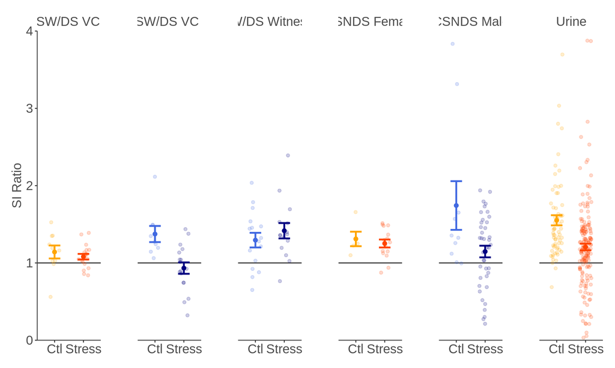

ANOVA: SI ratio in in Female CSW/DS witness mice in a validation cohort

|  | Df | Sum Sq | Mean Sq | F value | Pr(>F) |
| --- | --- | --- | --- | --- | --- |
| **Condition** | 1 | 0.02405 | 0.02405 | 0.6029 | 0.4445 |
| **Residuals** | 26 | 1.037 | 0.03989 | NA | NA |

ANOVA: SI ratio in in Male CSW/DS witness mice in a validation cohort

|  | Df | Sum Sq | Mean Sq | F value | Pr(>F) |
| --- | --- | --- | --- | --- | --- |
| **Condition** | 1 | 1.143 | 1.143 | 12.1 | 0.001943 |
| **Residuals** | 24 | 2.268 | 0.0945 | NA | NA |

ANOVA: SI ratio in Male CSW/DS witness mice

|  | Df | Sum Sq | Mean Sq | F value | Pr(>F) |
| --- | --- | --- | --- | --- | --- |
| **Condition** | 1 | 0.1147 | 0.1147 | 0.7853 | 0.3828 |
| **Residuals** | 29 | 4.235 | 0.146 | NA | NA |

ANOVA: SI ratio in Female CSNDS mice

|  | Df | Sum Sq | Mean Sq | F value | Pr(>F) |
| --- | --- | --- | --- | --- | --- |
| **Condition** | 1 | 0.01297 | 0.01297 | 0.3176 | 0.58 |
| **Residuals** | 18 | 0.7351 | 0.04084 | NA | NA |

ANOVA: SI ratio in Male CSNDS mice

|  | Df | Sum Sq | Mean Sq | F value | Pr(>F) |
| --- | --- | --- | --- | --- | --- |
| **Condition** | 1 | 2.834 | 2.834 | 7.646 | 0.008052 |
| **Residuals** | 48 | 17.79 | 0.3707 | NA | NA |

ANOVA: SI ratio in Urine Defeat

|  | Df | Sum Sq | Mean Sq | F value | Pr(>F) |
| --- | --- | --- | --- | --- | --- |
| **Condition** | 1 | 5.613 | 5.613 | 18.49 | 2.512e-05 |
| **Residuals** | 233 | 70.74 | 0.3036 | NA | NA |

### $\Delta$Velocity across female defeat models (Fig. 5a-d)

As shown in *Figure 4,* $\Delta$Velocity is significantly lower in CSW/DS female witnesses. Here, we demonstrate that $\Delta$Velocity shows a significant reduction in the CSW/DS VC females and following CSNDS, with a trending reduction in Urine model defeat and CSW/DS witness males. The lower effect size after Urine model defeat could relate to the more extreme SI ratio values observed in this model, which are incompatible with low $\Delta$Velocity values, as shown in *Figure 6.*

```r
DelVel <- ggplot(main_SIT_diff, aes(Condition, Velocity,
                 color = colcond, fill = colcond)) +
              geom_hline(yintercept = 0, color = 'gray80') +
              geom_jitter(width = 0.2, alpha = 0.2, height = 0) +
              stat_summary(fun = 'mean', geom = 'point', size = 2) +
              stat_summary(fun.data = 'mean_se', geom = 'errorbar',
                           linewidth = 1, width = 0.4) +
              facet_grid(. ~ model) +
              scale_y_continuous(name = expression(Delta*' Velocity')) +
              scale_color_manual(values = col_full) +
              scale_fill_manual(values = col_full) +
              plot_theme +
              theme(legend.position = 'None',
                    axis.title.x = element_blank(),
                    panel.spacing.x = unit(3, 'lines'),
                    strip.text = element_blank())

# STATS ----

# ANOVAs
aov_DelVel_CSWDS_VC_F <- summary(aov(Velocity ~ Condition, CSWDS_VC_F_data))
aov_DelVel_CSNDS_VC_M <- summary(aov(Velocity ~ Condition, CSWDS_VC_M_data))
aov_DelVel_CSWDS_Witness_M <- summary(aov(Velocity ~ Condition, CSWDS_Witness_M_data))
aov_DelVel_CSNDS_F <- summary(aov(Velocity ~ Condition, CSNDS_F_data))
aov_DelVel_CSNDS_M <- summary(aov(Velocity ~ Condition, CSNDS_M_data))
aov_DelVel_Urine <- summary(aov(Velocity ~ Condition, Urine_data))
```

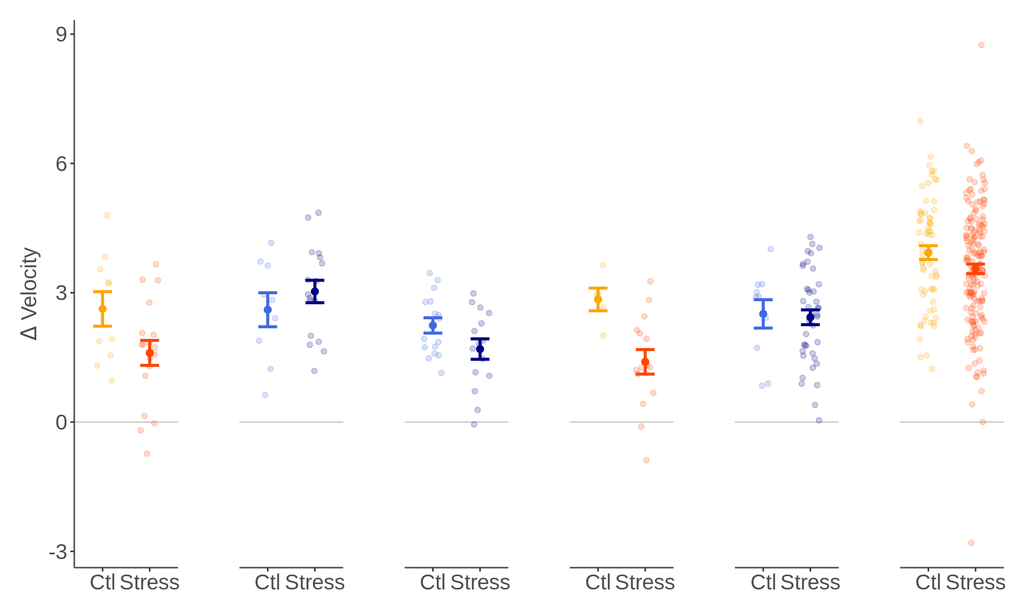

ANOVA: Delta Velocity in in Female CSW/DS witness mice in a validation cohort

|  | Df | Sum Sq | Mean Sq | F value | Pr(>F) |
| --- | --- | --- | --- | --- | --- |
| **Condition** | 1 | 6.691 | 6.691 | 4.333 | 0.04738 |
| **Residuals** | 26 | 40.15 | 1.544 | NA | NA |

ANOVA: Delta Velocity in in Male CSW/DS witness mice in a validation cohort

|  | Df | Sum Sq | Mean Sq | F value | Pr(>F) |
| --- | --- | --- | --- | --- | --- |
| **Condition** | 1 | 1.056 | 1.056 | 0.8541 | 0.3646 |
| **Residuals** | 24 | 29.68 | 1.237 | NA | NA |

ANOVA: Delta Velocity in Male CSW/DS witness mice

|  | Df | Sum Sq | Mean Sq | F value | Pr(>F) |
| --- | --- | --- | --- | --- | --- |
| **Condition** | 1 | 2.325 | 2.325 | 3.481 | 0.07224 |
| **Residuals** | 29 | 19.37 | 0.6679 | NA | NA |

ANOVA: Delta Velocity in Female CSNDS mice

|  | Df | Sum Sq | Mean Sq | F value | Pr(>F) |
| --- | --- | --- | --- | --- | --- |
| **Condition** | 1 | 7.859 | 7.859 | 7.693 | 0.01252 |
| **Residuals** | 18 | 18.39 | 1.022 | NA | NA |

ANOVA: Delta Velocity in Male CSNDS mice

|  | Df | Sum Sq | Mean Sq | F value | Pr(>F) |
| --- | --- | --- | --- | --- | --- |
| **Condition** | 1 | 0.04997 | 0.04997 | 0.04303 | 0.8365 |
| **Residuals** | 48 | 55.74 | 1.161 | NA | NA |

ANOVA: Delta Velocity in Urine Defeat

|  | Df | Sum Sq | Mean Sq | F value | Pr(>F) |
| --- | --- | --- | --- | --- | --- |
| **Condition** | 1 | 6.689 | 6.689 | 3.451 | 0.06446 |
| **Residuals** | 233 | 451.6 | 1.938 | NA | NA |

### Effect sizes across female defeat models (Fig. 5e)

To account for differences in sample size in the datasets used in the study we also provide effect sizes to compare mean differences across different female defeat models.

Hedge’s g effect sizes across models for SI Ratio and Delta Velocity

| model | Sex | other | SI Ratio | Velocity |
| --- | --- | --- | --- | --- |
| CSNDS Female | Female | Standard | 0.2787015 | 1.3716456 |
| CSNDS Male | Male | Standard | 0.9622328 | 0.0721877 |
| CSW/DS VC F | Female | None | 0.2973039 | 0.7969951 |
| CSW/DS VC M | Male | None | 1.3885682 | 0.3689306 |
| CSW/DS Witness M | Male | MaleWitness | 0.3101683 | 0.6529849 |
| Urine | Female | None | 0.6250573 | 0.2700475 |

### Models of inter-female aggression (Fig. S5)

#### Mus Muculus (Swiss Webster)

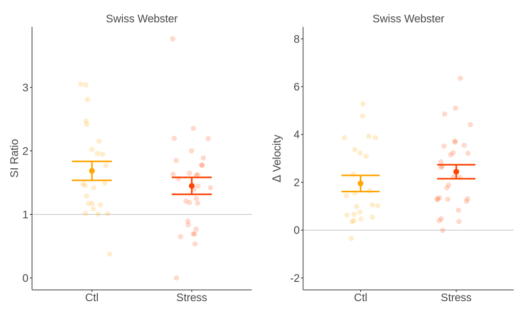

ANOVA: SI ratio in Mus Muculus (Swiss Webster) model of inter-female aggression.

|  | Df | Sum Sq | Mean Sq | F value | Pr(>F) |
| --- | --- | --- | --- | --- | --- |
| **Condition** | 1 | 0.7162 | 0.7162 | 1.397 | 0.2428 |
| **Residuals** | 50 | 25.63 | 0.5127 | NA | NA |

ANOVA: Delta Velocity in Mus Muculus (Swiss Webster) model of inter-female aggression.

|  | Df | Sum Sq | Mean Sq | F value | Pr(>F) |
| --- | --- | --- | --- | --- | --- |
| **Condition** | 1 | 3.084 | 3.084 | 1.212 | 0.2762 |
| **Residuals** | 50 | 127.2 | 2.544 | NA | NA |

#### Peromyscus californicus (California Mouse)

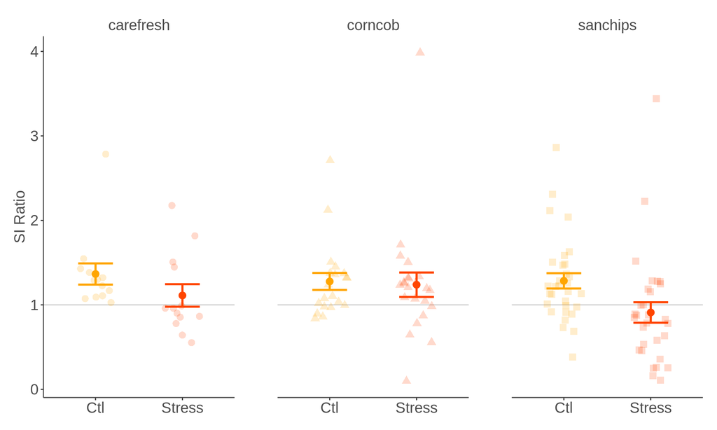

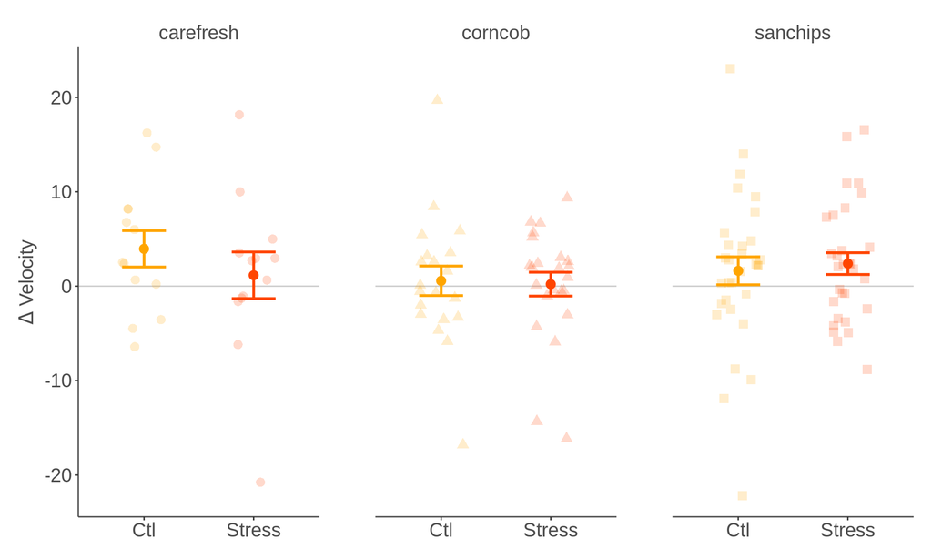

ANOVA: SI ratio in P. Californicus model of inter-female aggression.

|  | Df | Sum Sq | Mean Sq | F value | Pr(>F) |
| --- | --- | --- | --- | --- | --- |
| **Condition** | 1 | 1.79 | 1.79 | 5.533 | 0.02023 |
| **other** | 2 | 0.8057 | 0.4029 | 1.245 | 0.2914 |
| **Condition:other** | 2 | 0.7097 | 0.3549 | 1.097 | 0.3371 |
| **Residuals** | 124 | 40.11 | 0.3235 | NA | NA |

Comparisons SI ratio

| contrast | other | estimate | SE | df | t.ratio | p.value |
| --- | --- | --- | --- | --- | --- | --- |
| Ctl - Stress | carefresh | 0.2538308 | 0.2230828 | 124 | 1.1378322 | 0.2573843 |
| Ctl - Stress | corncob | 0.0390998 | 0.1738914 | 124 | 0.2248521 | 0.8224645 |
| Ctl - Stress | sanchips | 0.3747260 | 0.1456620 | 124 | 2.5725720 | 0.0112733 |

ANOVA: Delta Velocity in P. Californicus model of inter-female aggression.

|  | Df | Sum Sq | Mean Sq | F value | Pr(>F) |
| --- | --- | --- | --- | --- | --- |
| **Condition** | 1 | 4.722 | 4.722 | 0.09063 | 0.7639 |
| **other** | 2 | 96.55 | 48.27 | 0.9265 | 0.3986 |
| **Condition:other** | 2 | 57.83 | 28.91 | 0.555 | 0.5755 |
| **Residuals** | 124 | 6460 | 52.1 | NA | NA |

Comparisons Delta Velocity

| contrast | other | estimate | SE | df | t.ratio | p.value |
| --- | --- | --- | --- | --- | --- | --- |
| Ctl - Stress | carefresh | 2.8005128 | 2.831155 | 124 | 0.9891769 | 0.3245029 |
| Ctl - Stress | corncob | 0.3529565 | 2.206864 | 124 | 0.1599358 | 0.8731919 |
| Ctl - Stress | sanchips | -0.7612115 | 1.848603 | 124 | -0.4117765 | 0.6812141 |